# O centro presidencial no Brasil

Igor Brito, mat. 21/0005131

Setembro, 2022

## Objetivo

- O objetivo deste trabalho é analisar o efeito da quantidade de partidos no gabinete no tamanho do centro presidencial no Brasil
- O centro presidencial pode ser entendido como o núcleo que apoia diretamente o trabalho do chefe de governo e busca reforçar sua autoridade e liderança, bem como sua autonomia e recursos políticos, articulando dispositivos de centralização de poderes dentro do Executivo (Lanzaro 2018).

## Contextualização

- O presidente é um ator fundamental na dinâmica política, social e econômica dos países presidencialistas e a reorganização das estruturas que o apoiam em sua missão institucional tem sido uma preocupação recorrente entre formuladores de políticas e organizações multilaterais nas últimas décadas.
- Nesse contexto, o tamanho do centro presidencial é um aspecto relevante por representar a extensão do núcleo que provê suporte imediato ao presidente na condução do governo, principalmente quando ele lida com um ambiente hostil que ameaça sua autonomia e controle.

## Contextualização

- Em gabinetes de coalizão, quando o presidente cede espaço no gabinete a outros partidos para assegurar uma cooperação estável com o Legislativo, há o risco de os ministros perseguirem agendas próprias e de seus partidos, ameaçando a autonomia e o controle presidencial. Para lidar com esse risco, o presidente tenderia a expandir o centro presidencial.
- *H1: O centro presidencial expandirá quanto maior for a quantidade de partidos no gabinete.*

## Métodos

- Fonte de dados:
  - Centro presidencial (1985-2002): Inácio e Llanos (2015)
  - Centro presidencial (2003-2016): normas de organização do Poder Executivo
  - Partidos no gabinete (1985-2016): Amorim Neto (2019)
- Modelo de regressão linear, sendo H1 representada por $\beta_1 \neq 0$:

$tam\_cp = \beta_0 + \beta_1*qtd\_part$

## Amostra dos dados brutos

| ano | tam_cp | gabinete | qtd_part | partidos |
| --- | --- | --- | --- | --- |
| 2001 | 12 | Cardoso II-2 | 5 | PSDB, PFL, PMDB, PPB, PPS |
| 2003 | 21 | Lula da Silva I-1 | 8 | PT, PTB, PL, PSB, PPS, PDT, PCdoB, PV |
| 2006 | 21 | Lula da Silva I-3 | 9 | PT, PMDB, PTB, PL, PSB, PPS, PCdoB, PV, PP |
| 2012 | 23 | Rousseff I-2 | 6 | PT, PMDB, PP, PR, PSB, PCdoB |
| 2013 | 23 | Rousseff I-3 | 8 | PT, PMDB, PP, PR, PSB, PCdoB, PRB, PDT |

## Estatísticas descrtitivas

```
##      tam_cp         qtd_part
##  Min.   : 6.00   Min.   : 2.000
##  1st Qu.:10.75   1st Qu.: 3.750
##  Median :14.50   Median : 6.000
##  Mean   :15.41   Mean   : 5.844
##  3rd Qu.:21.00   3rd Qu.: 8.000
##  Max.   :24.00   Max.   :10.000
```

## Gráfico de dispersão e modelo linear

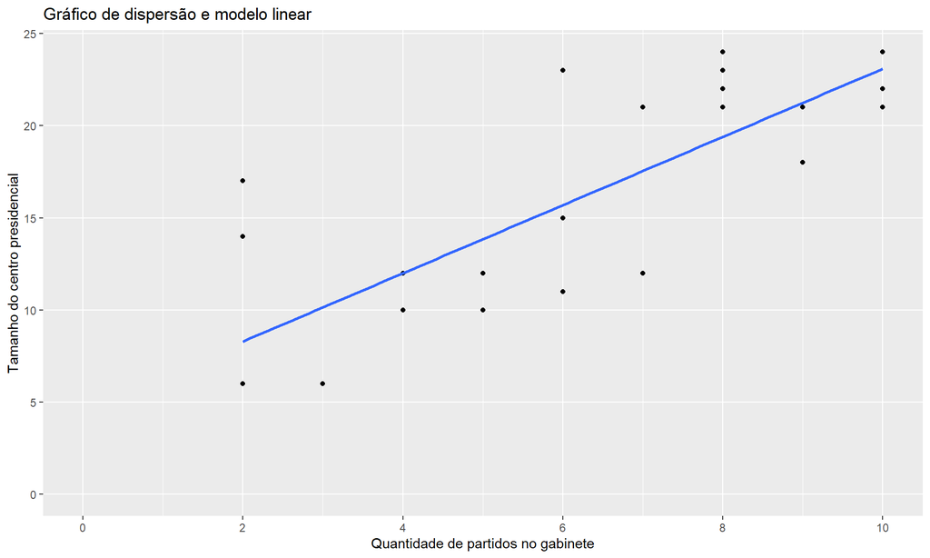

## Tabela de regressão

| term | estimate | std_error | statistic | p_value | lower_ci | upper_ci |
| --- | --- | --- | --- | --- | --- | --- |
| intercept | 4.589 | 1.621 | 2.831 | 0.008 | 1.279 | 7.900 |
| qtd_part | 1.851 | 0.253 | 7.325 | 0.000 | 1.335 | 2.367 |

- O coeficiente estimado de $qtd\_part$ é 1.9 aproximadamente. Ou seja, para cada acréscimo de um partido no gabinete, existe um acréscimo associado, em média, de 1.9 órgãos no centro presidencial.
- O intervalo de confiança de 95% para esse parâmetro é [1.335, 2.367].
- O p-valor é baixíssimo (< 0.000), portanto, esse resultado é significante estatisticamente aos níveis convencionais de confiança (10%, 5%, 1% e 0.1%).

## Conclusões e limitações

- Os resultados evidenciaram uma associação positiva e estatisticamente significante entre essas variáveis.
- Contudo, esses resultados devem ser encarados como provisórios, considerando as limitações de quantidade de observações utilizadas na análise e de emprego de uma técnica de análise modesta (regressão linear simples) que não trata algumas características dos dados utilizados (como a dependência das observações).

## Referências

Amorim Neto, Octavio. 2019. «Cabinets and coalitional presidentialism». Em *Routledge Handbook of Brazilian Politics*, editado por Barry Ames, 293–312. New York: Routledge.

Inácio, Magna, e Mariana Llanos. 2015. «The Institutional Presidency from a Comparative Perspective: Argentina and Brazil since the 1980s». *Brazilian Political Science Review* 9 (1): 39–64. https://doi.org/10.1590/1981-38212014000200002.

Lanzaro, Jorge. 2018. «Introducción». Em *Centro Presidencial: presidencias y centros de gobierno en América Latina, Estados Unidos y Europa*, editado por Jorge Lanzaro, 13–38. Madrid: Tecnos.